# Lab #5

Kobe Pranivong; Yi Hang Khor

4/15/2020

```r
accident <- read.csv("https://raw.githubusercontent.com/xdaiISU/ds202materials/master/hwlabs/fars2017/accident.csv", stringsAsFactors = FALSE)
person <- read.csv("https://raw.githubusercontent.com/xdaiISU/ds202materials/master/hwlabs/fars2017/person.csv", stringsAsFactors = FALSE)
table(accident$DAY_WEEK)
```

```
##
##    1    2    3    4    5    6    7
## 5360 4374 4347 4314 4621 5358 5873
```

### Part 1

1. Are there some days of the week where more accidents happen than on others (use variable DAY_WEEK)?

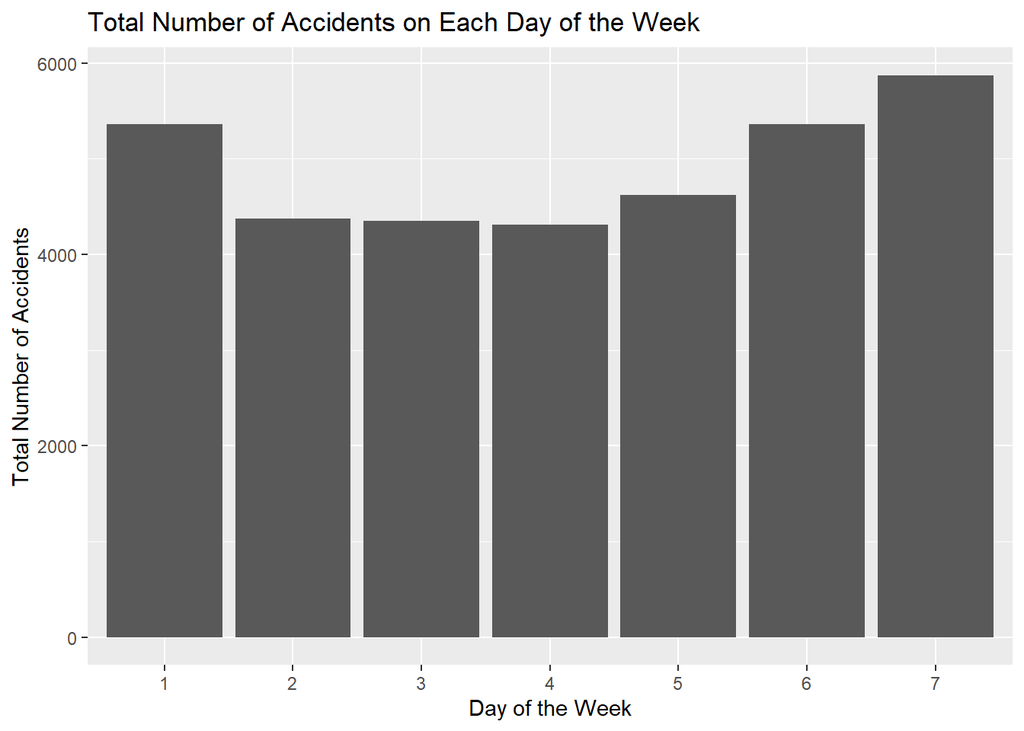

```r
ggplot(accident, aes(x = DAY_WEEK, label = TRUE)) + geom_bar() + ylab("Total Number of Accidents") + ggtitle("Total Number of Accidents on Each Day of the Week") + scale_x_discrete(name ="Day of the Week", limits=1:7)
```

The last day of the week (day 7/Saturday) has the greatest number of accidents. In general, weekeneds (day 1, 6, and 7/Friday, Saturday, and Sunday) experience more accidents than weekdays.

2. What time of the day do accidents happen (use variable HOUR)?

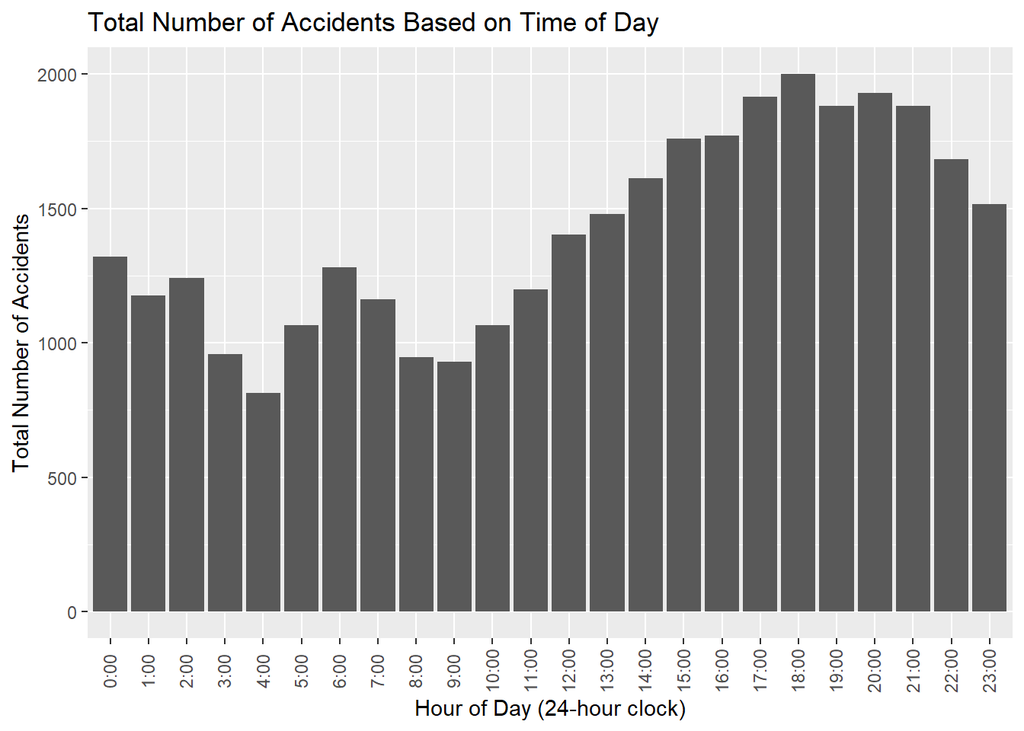

```r
accident %>%
  filter(HOUR < 24) %>%
  ggplot(mapping = aes(x = factor(as.factor(paste(HOUR,":00",sep = "")), levels = c("0:00","1:00","2:00","3:00","4:00","5:00","6:00","7:00","8:00","9:00","10:00","11:00","12:00","13:00","14:00","15:00","16:00","17:00","18:00","19:00","20:00","21:00","22:00","23:00")))) + geom_bar() + xlab("Hour of Day (24-hour clock)") + ylab("Total Number of Accidents") + ggtitle("Total Number of Accidents Based on Time of Day") + theme(axis.text.x = element_text(angle = 90, vjust = .4))
```

Most accidents tend to occur later in the day between 15 hours and 22 hours, also known as 3:00pm - 10:00pm.

3. What is the number of accidents with at least one drunk driver (use variable DRUNK_DR)?

```r
drunk_count <- accident %>%
  count(DRUNK_DR > 0)
drunk_count
```

```
## # A tibble: 2 x 2
##   `DRUNK_DR > 0`     n
##   <lgl>          <int>
## 1 FALSE          25478
## 2 TRUE            8769
```

8769 accidents had at least one drunk driver.

### Part 2

4. In the person table, identify drivers (PER_TYP == 1, see FARS manual) and subset on them.

```r
driver <- person %>%
  filter(PER_TYP == 1)
```

5. Join accident and person table (work out which variable(s) to use)

```r
data <- accident %>%
  full_join(driver, by = c('STATE', 'ST_CASE', 'COUNTY', 'DAY', 'MONTH', 'HOUR', 'MINUTE'))
```

6. Tally the number of accidents by day of the week (DAY_WEEK), hour of the day (HOUR) and gender (SEX). Visualize the results.

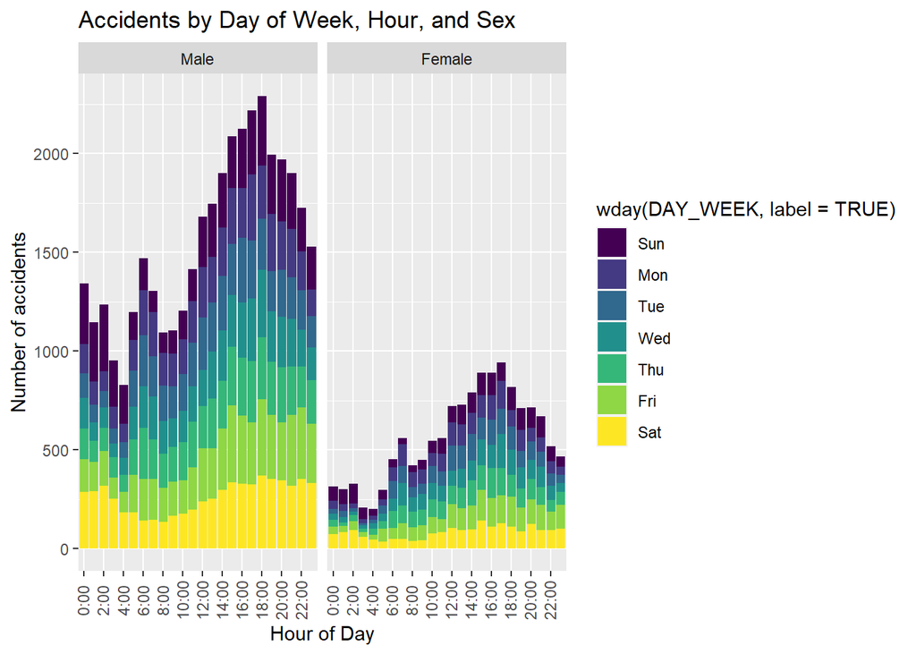

```r
data$SEX <- factor(data$SEX, labels = c("Male","Female", "Not Reported", "Unknown"))
data %>%
  filter(SEX == 'Male' | SEX == 'Female') %>%
  filter(HOUR <= 24) %>%
  ggplot(aes(x = factor(as.factor(paste(HOUR,":00",sep = "")), levels =  c("0:00","1:00","2:00","3:00","4:00","5:00","6:00","7:00","8:00","9:00","10:00","11:00","12:00","13:00","14:00","15:00","16:00","17:00","18:00","19:00","20:00","21:00","22:00","23:00")), fill = wday(DAY_WEEK, label = TRUE))) + geom_bar() + facet_wrap(~SEX) + xlab("Hour of Day") + ylab("Number of accidents") + ggtitle("Accidents by Day of Week, Hour, and Sex") + theme(axis.text.x = element_text(angle = 90, vjust = .4)) + scale_x_discrete(breaks=c("0:00","2:00","4:00","6:00","8:00","10:00","12:00","14:00","16:00","18:00","20:00","22:00"))
```

### Part 3

7. Now plot a choropleth map of accidents on a county level

Read the description for the STATE and COUNTY columns in the FARS manual. The state & county codes are Geographic Locator Codes (GLCs) from the General Services Administration’s (GSA) publication Use readxl::read_xlsx to read in the GLCs

```r
US_GLC <- readxl::read_xlsx('FRPP_GLC_UnitedStatesFeb132020.xlsx')
county <- ggplot2::map_data("county")
```

8. Visualize the number of accidents in each county using a choropleth map. To do this, you need to join the accident data, GLCs, and appropriate map data.

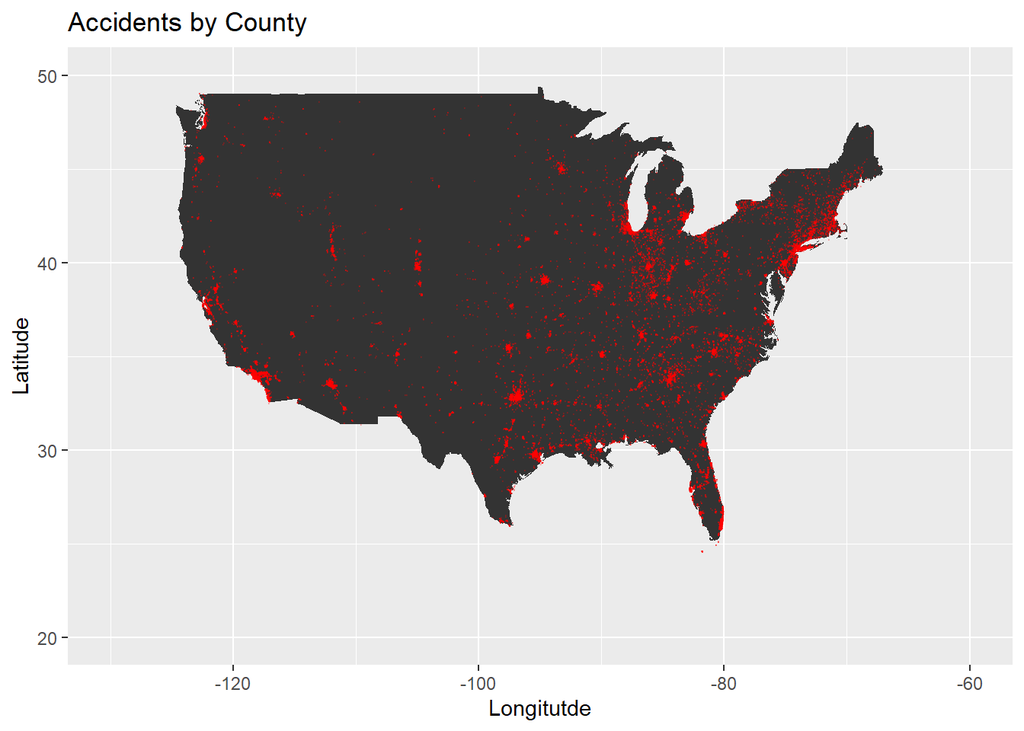

```r
US_GLC2 <- US_GLC %>%
  mutate(`State Code` = as.integer(`State Code`), `County Code` = as.integer(`County Code`), `City Code` = as.integer(`City Code`)) %>%
  inner_join(data, c(`County Code` = 'COUNTY', `State Code` = 'STATE', `City Code` = 'CITY'))
ggplot(county, mapping=aes(x = long, y = lat)) + geom_polygon(mapping = aes(group = group, fill = )) + geom_point(US_GLC2, mapping = aes(x = LONGITUD, y = LATITUDE), color = 'red', alpha = .2, size = .02) + xlim(c(-130, -60)) + ylim(c(20,50)) + xlab('Longitutde') + ylab('Latitude') + ggtitle('Accidents by County')
```

9. Can you find seasonal trends in accident occurrences in different states? Is summer or winter more dangerous? Why?

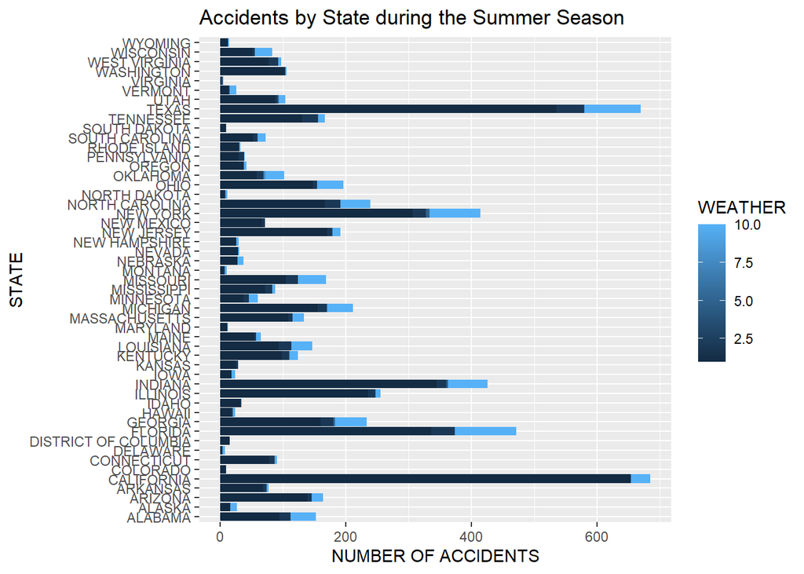

```r
US_GLC2 %>%
  filter(MONTH == 6 | MONTH == 7 | MONTH == 8) %>%
  filter(WEATHER < 98) %>%
  group_by(`State Name`, WEATHER, MONTH) %>%
  summarise(n = n()) %>%
  ggplot(acc, mapping = aes(x=`State Name`, y=n, fill = WEATHER)) + geom_col() + coord_flip() + xlab('STATE') + ylab('NUMBER OF ACCIDENTS') + ggtitle("Accidents by State during the Summer Season")
```

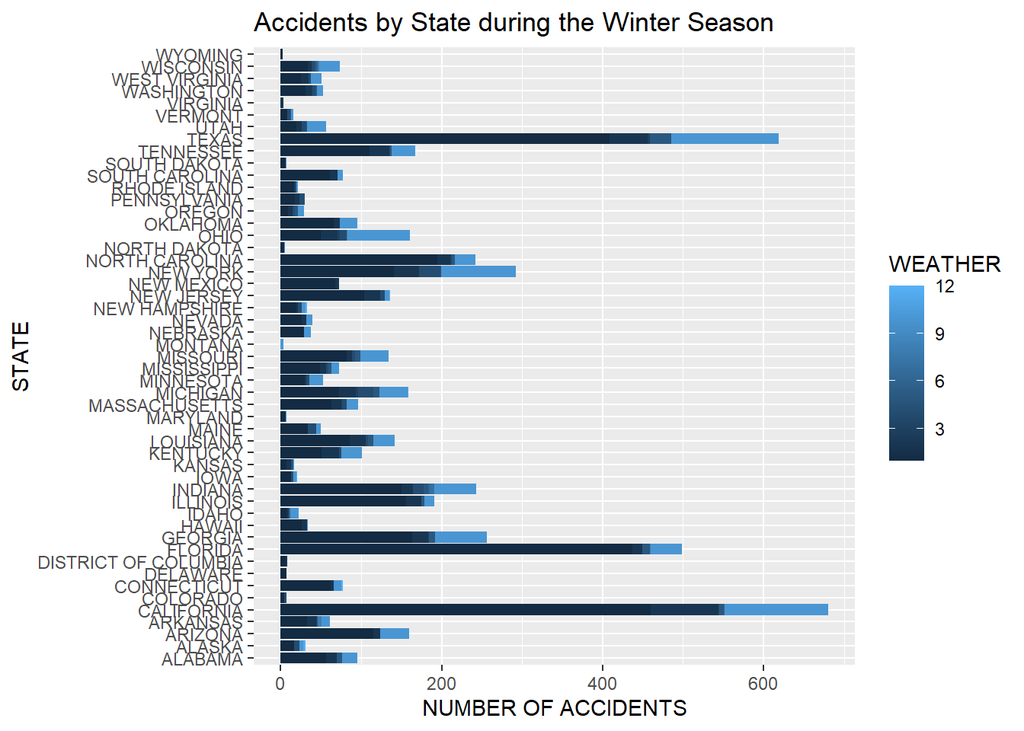

```r
US_GLC2 %>%
  filter(MONTH == 12 | MONTH == 1 | MONTH == 2) %>%
  filter(WEATHER < 98) %>%
  group_by(`State Name`, WEATHER, MONTH) %>%
  summarise(n = n()) %>%
  ggplot(acc, mapping = aes(x=`State Name`, y=n, fill = WEATHER)) + geom_col() + coord_flip() + xlab('STATE') + ylab('NUMBER OF ACCIDENTS') + ggtitle("Accidents by State during the Winter Season")
```